# VAT08 Stage 1 and 2 Data

### nAb immunogenicity and imputation

Note that the marker level in the NN, placebo is higher in Stage 2 than in Stage 1, probably reflecting different countries.

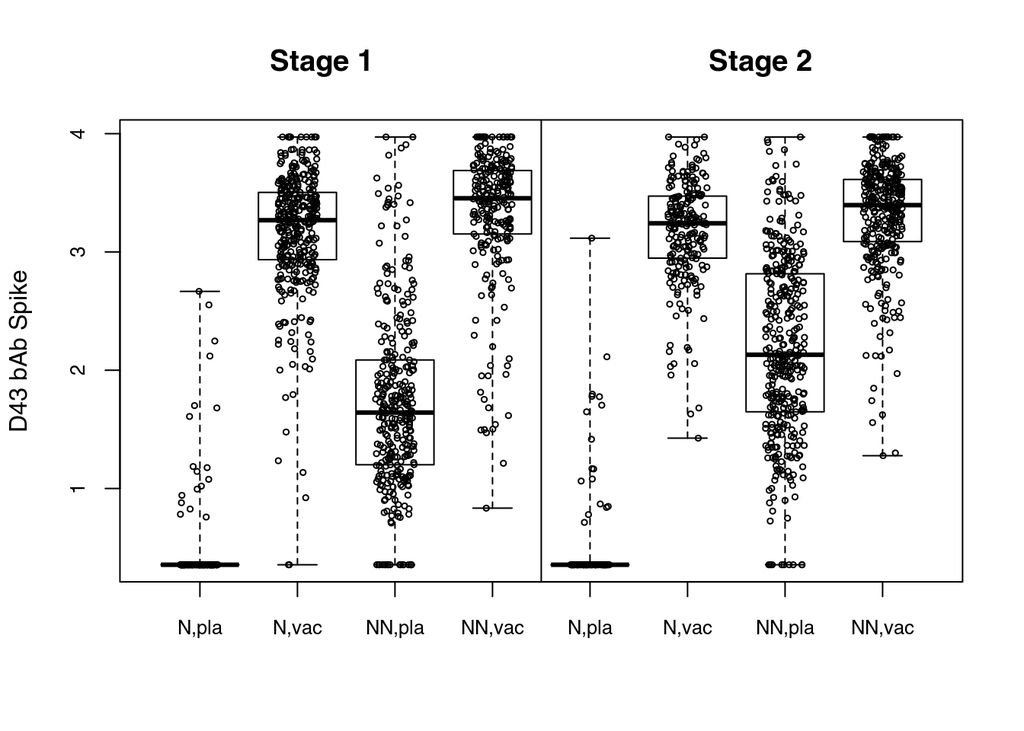

```r
myboxplot(Day43bindSpike~Trt+Bserostatus+Trialstage, dat_mapped, ylab="D43 bAb Spike",
  names=rep(c("N,pla", "N,vac", "NN,pla", "NN,vac"),2),
  main="Stage 1                                        Stage 2",
  cex.axis=0.8)
abline(v=4.5)
```

There are five different ID50s and one score.

```r
assays=assays[startsWith(assays,"pseudoneutid50")]
print(assays)
```

```
## [1] "pseudoneutid50"         "pseudoneutid50_B.1.351" "pseudoneutid50_BA.1"
## [4] "pseudoneutid50_BA.2"    "pseudoneutid50_BA.4.5"  "pseudoneutid50_mdw"
```

Correlation is high between variant markers in Stage 2 non-naive, vaccine arm at both baseline

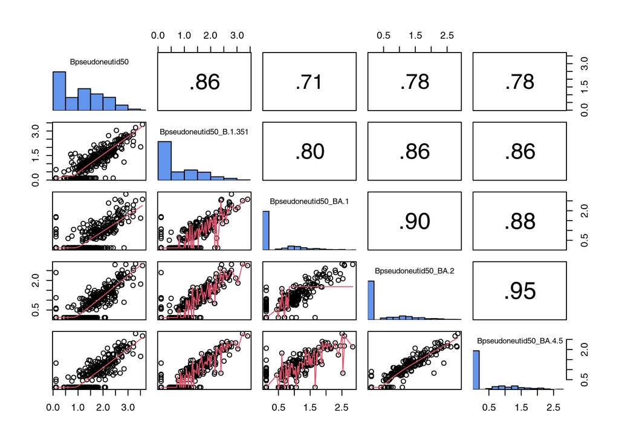

```r
mypairs(subset(dat_proc, Trialstage==2 & Bserostatus==1 & Trt==1 & ph1.D43)[,"B"%.%assays[1:5]])
```

and D43

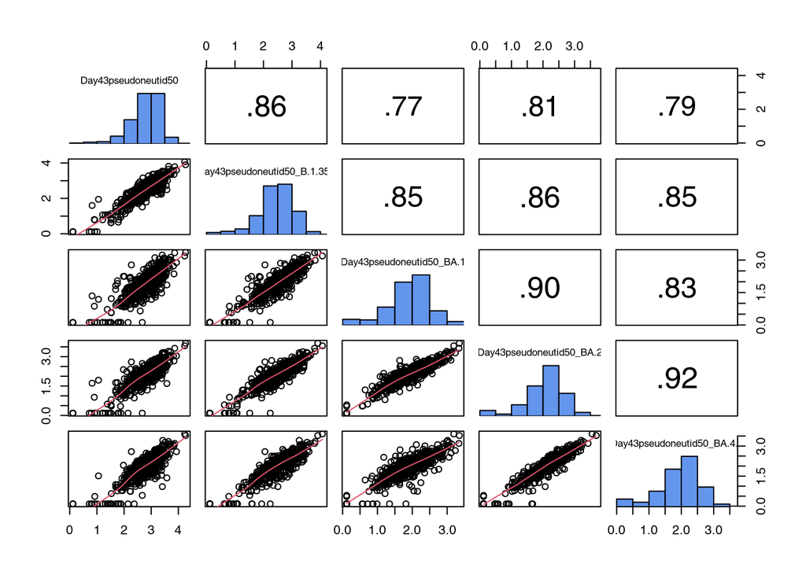

```r
mypairs(subset(dat_proc, Trialstage==2 & Bserostatus==1 & Trt==1 & ph1.D43)[,"Day43"%.%assays[1:5]])
```

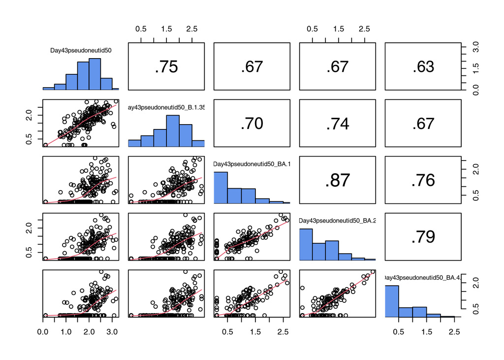

```r
mypairs(subset(dat_proc, Trialstage==2 & Bserostatus==0 & Trt==1 & ph1.D43)[,"Day43"%.%assays[1:5]])
```

Correlation is low between baseline and D22 or D43 in Stage 2 non-naive, vaccine arm.

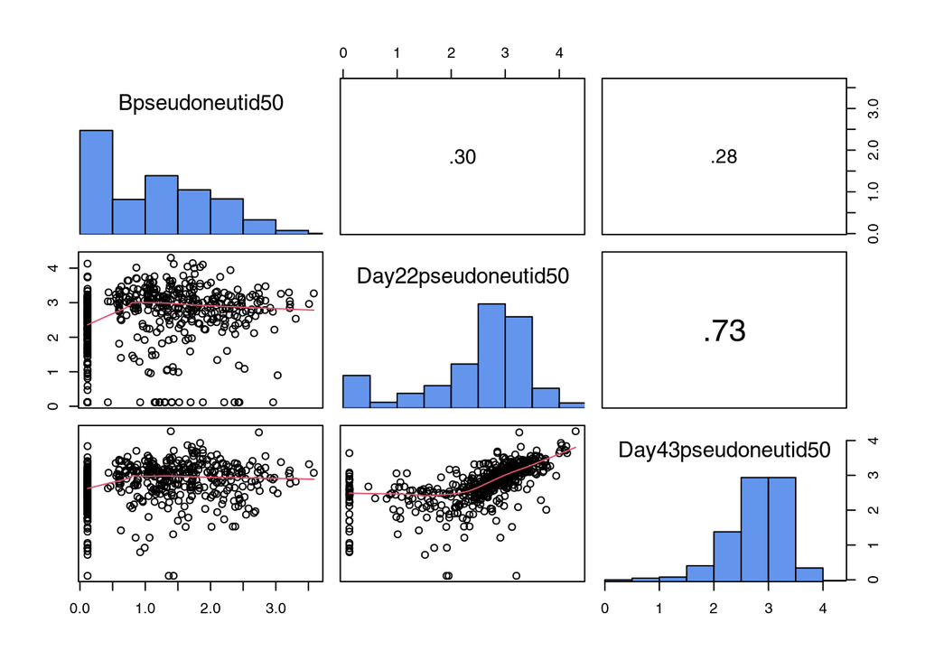

```r
mypairs(subset(dat_proc, Trialstage==2 & Bserostatus==1 & Trt==1 & ph1.D43)[,c("B","Day22","Day43")%.%assays[1]])
```

A closer look at the relationship between baseline and Day 43 markers in the baseline positive. Note that the D43 markers appear saturated since level seems flat across different baseline marker levels.

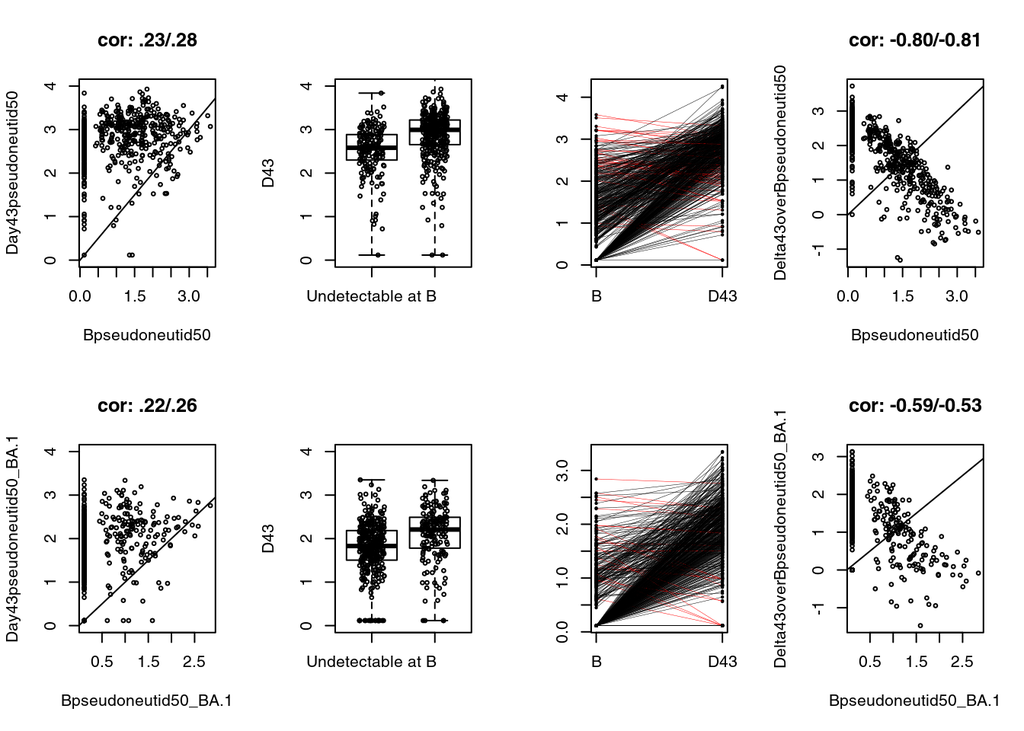

```r
par(mfrow=c(2,4))
  # ancestral marker
  corplot(Day43pseudoneutid50~Bpseudoneutid50, subset(dat_proc, Trialstage==2 & Bserostatus==1 & Trt==1 & ph1.D43), ylim=c(0,4))
  myboxplot(Day43pseudoneutid50~I(Bpseudoneutid50>0.2), subset(dat_proc, Trialstage==2 & Bserostatus==1 & Trt==1 & ph1.D43), names=c("Undetectable at B","Detectable at B"), ylab="D43", ylim=c(0,4))
  my.interaction.plot(subset(dat_proc, Trialstage==2 & Bserostatus==1 & Trt==1 & ph1.D43 & !is.na(Bpseudoneutid50) & !is.na(Day43pseudoneutid50), c(Bpseudoneutid50, Day43pseudoneutid50)),
                      x.ori = 0, xaxislabels = c("B", "D43"), cex.axis = 1, add = FALSE, xlab = "", ylab = "", pcol = NULL, lcol = NULL)
  corplot(Delta43overBpseudoneutid50~Bpseudoneutid50, subset(dat_proc, Trialstage==2 & Bserostatus==1 & Trt==1 & ph1.D43))

  # BA.1
  corplot(Day43pseudoneutid50_BA.1~Bpseudoneutid50_BA.1, subset(dat_proc, Trialstage==2 & Bserostatus==1 & Trt==1 & ph1.D43), ylim=c(0,4))
  myboxplot(Day43pseudoneutid50_BA.1~I(Bpseudoneutid50_BA.1>0.2), subset(dat_proc, Trialstage==2 & Bserostatus==1 & Trt==1 & ph1.D43), names=c("Undetectable at B","Detectable at B"), ylab="D43", ylim=c(0,4))
  my.interaction.plot(subset(dat_proc, Trialstage==2 & Bserostatus==1 & Trt==1 & ph1.D43 & !is.na(Bpseudoneutid50_BA.1) & !is.na(Day43pseudoneutid50_BA.1), c(Bpseudoneutid50_BA.1, Day43pseudoneutid50_BA.1)),
                      x.ori = 0, xaxislabels = c("B", "D43"), cex.axis = 1, add = FALSE, xlab = "", ylab = "", pcol = NULL, lcol = NULL)
  corplot(Delta43overBpseudoneutid50_BA.1~Bpseudoneutid50_BA.1, subset(dat_proc, Trialstage==2 & Bserostatus==1 & Trt==1 & ph1.D43))
```

Overall, “because the correlation among variants is pretty good for the non-naives and really the analysis focuses on the non-naives” (Peter), we decide to **impute variants for those who have data for at least one variant to make the complexity of data processing more manageable**.

Missingness across baseline, d22 and d43, for the ancestral markers in the vaccine arms. The results support the decision “**to keep it simple and require for RIS membership availability of data at all 3 time points**” (Peter).

```r
for(trt in 1:0) {
  myprint(trt)
  for (i in 2:1) {
    cat(paste0("stage ", i, '\n'))
    dat=subset(dat_proc, Trialstage==i & Trt==trt & ph1.D43)
    times=c("B","Day22","Day43")
    for (i in 1:3) {
      dat[['tmp'%.%i]]=ifelse(is.na(dat[[times[i]%.%'pseudoneutid50']]), 0, 1)
    }
    dat$tmp=with(dat,paste0(tmp1,tmp2,tmp3))
    print(table(dat$tmp))
    cat("\n")
  }
}
```

```
## trt = 1
## stage 2
##
##  000  001  011  101  110  111
## 4338    4    6    1   11  713
##
## stage 1
##
##  000  010  011  100  101  110  111
## 2961   12   28   45   15   29  956
##
## trt = 0
## stage 2
##
##  000  001  011  100  101  110  111
## 4377    2    5    1    3    2  562
##
## stage 1
##
##  000  001  010  011  100  101  110  111
## 3210    2    3   10   31   10   24  827
```

Missingness across variants. Some ptids only have the ancestral marker measured. The missingness pattern is explained by the fact that samples from different steps have different set of markers measured. We decide to impute all variants if one variant marker exists.

```r
# for (tp in c("B")) {
for (tp in c("B", "Day22", "Day43")) {
  # before imputation
  dat1=dat_mapped
  # after imputation
  # dat1=dat_proc

  for(trt in 1) {
    myprint(tp, trt)
    for (i in 2:1) {
      cat(paste0("stage ", i, '\n'))
      if (trt==2) {
        # pool over arms
        dat=subset(dat1, Trialstage==i & ph1.D43)
      } else {
        dat=subset(dat1, Trialstage==i & ph1.D43 & Trt==trt)
      }
      for (i in 1:5) {
        dat[['tmp'%.%i]]=ifelse(is.na(dat[[tp%.%assays[i]]]), 0, 1)
      }
      dat$tmp=with(dat,paste0(tmp1,tmp2,tmp3,tmp4,tmp5))
      print(table(dat$tmp))
      cat("\n")
      # print(table(dat$EventIndPrimaryD43, dat$tmp, dat$Bserostatus))
    }
  }

}
```

```
## tp = B ; trt = 1
## stage 2
##
## 00000 00111 01101 01111 10001 10010 10100 10101 10110 10111 11000 11001 11010
##  4375     5     2    26     3     1     2     3     3    18    10     1     5
## 11011 11100 11101 11110 11111
##    15     6    11    18   600
##
## stage 1
##
## 00000 00110 01110 01111 10000 10100 10101 10110 10111 11000 11001 11010 11011
##  3019     1    14     3   454     2     1     9     4     3     2     3     4
## 11100 11101 11110 11111
##     6     3   457   107
##
## tp = Day22 ; trt = 1
## stage 2
##
## 00000 00010 00111 01011 01101 01111 10000 10110 10111 11000 11001 11010 11011
##  4370     1     3     1     1    11     4     2     8     1     2     3     6
## 11100 11101 11110 11111
##     3     8     4   676
##
## stage 1
##
## 00000 00110 01110 01111 10000 10110 10111 11000 11010 11110 11111
##  3045     1    19     3   430    10     2     3     3   454   122
##
## tp = Day43 ; trt = 1
## stage 2
##
## 00000 00111 01111 10000 10100 10110 10111 11000 11001 11010 11011 11100 11101
##  4376     6     3     6     1     2    11     7     2     2    16     1     9
## 11110 11111
##    12   650
##
## stage 1
##
## 00000 00110 01110 10000 10010 10100 10101 10110 10111 11000 11001 11010 11011
##  3072     2     5   402     1     4     1    19     4    16     3    21     6
## 11100 11101 11110 11111
##    20     2   407   107
```

```r
# a more detailed look at missingness by batch
# for (tp in c("B")) {
# #for (tp in c("B", "Day22", "Day43")) {
#   # before imputation
#   dat1=dat_mapped
#   # after imputation
#   # dat1=dat_proc
#
#   for(trt in 1) {
#     myprint(tp, trt)
#     for (i in 2:1) { # stage
#       cat(paste0("stage ", i, '\n'))
#       if (trt==2) {
#         # pool over arms
#         dat=subset(dat1, Trialstage==i & ph1.D43)
#       } else {
#         dat=subset(dat1, Trialstage==i & ph1.D43 & Trt==trt)
#       }
#       for (i in 1:5) {
#         dat[['tmp'%.%i]]=ifelse(is.na(dat[[tp%.%assays[i]]]), 0, 1)
#       }
#       dat$tmp=with(dat,paste0(tmp1,tmp2,tmp3,tmp4,tmp5))
#       print(mytable(dat$EventIndPrimaryD43, dat$tmp, dat$nAbBatch, dat$Bserostatus))
#     }
#   }
#
# }
```

The number of D43 nAb ph2 samples by Bserostatus 0/1 (row) and Case 1/0 (column) and broken down by treatment arms (vaccine, placebo).

```r
dat1=dat_proc

f=function(tab2, tab1, tab0) {
  for (i in 1:2) {
    print(paste0(tab2[i,1], " (", tab1[i,1], ", ", tab0[i,1], ") ", tab2[i,2], " (", tab1[i,2], ", ", tab0[i,2], ")"))
  }
}

for (i in 2:1) {
  cat(paste0("stage ", i, '\n'))
  dat=subset(dat1, Trialstage==i & ph1.D43 & TwophasesampIndD43nAb)
  tab2 = table(dat$Bserostatus, dat$EventIndPrimaryD43)[,2:1] # [,2:1] moves cases before non-cases
  dat=subset(dat1, Trialstage==i & ph1.D43 & Trt==1 & TwophasesampIndD43nAb)
  tab1 = table(dat$Bserostatus, dat$EventIndPrimaryD43)[,2:1] # [,2:1] moves cases before non-cases
  dat=subset(dat1, Trialstage==i & ph1.D43 & Trt==0 & TwophasesampIndD43nAb)
  tab0 = table(dat$Bserostatus, dat$EventIndPrimaryD43)[,2:1] # [,2:1] moves cases before non-cases
  f(tab2, tab1, tab0)
}
```

```
## stage 2
## [1] "41 (17, 24) 232 (179, 53)"
## [1] "122 (61, 61) 884 (457, 427)"
## stage 1
## [1] "150 (74, 76) 630 (382, 248)"
## [1] "179 (68, 111) 849 (447, 402)"
```

### Check which ptids are in which batch

We have list of ptids sampled in step 2 in both stages of the trial.

```r
stage2step2=read.csv("~/Aiying700.csv")
dat_mapped$stage2step2 = dat_mapped$Subjectid %in% stage2step2$Unique.Subject.Identifier
dat_proc$stage2step2 = dat_proc$Ptid %in% stage2step2$Unique.Subject.Identifier

stage1step2=read.csv("~/JinStage1Step2.csv")
dat_mapped$stage1step2 = dat_mapped$SUBJID %in% stage1step2$SUBJID
dat_proc$stage1step2 = dat_proc$SUBJID %in% stage1step2$SUBJID
```

Stage 2, nAb. batch 1 = step2 for both cases and noncases

```r
with(subset(dat_proc, Trt==1 & Trialstage==2 & ph2.D43.nAb), table(stage2step2, EventIndPrimaryD1, nAbBatch))
```

```
## , , nAbBatch = 1
##
##            EventIndPrimaryD1
## stage2step2   0   1
##       FALSE   0   0
##       TRUE  286  24
##
## , , nAbBatch = 2
##
##            EventIndPrimaryD1
## stage2step2   0   1
##       FALSE 350  54
##       TRUE    0   0
```

```r
with(subset(dat_proc, Trt==0 & Trialstage==2 & ph2.D43.nAb), table(stage2step2, EventIndPrimaryD1, nAbBatch))
```

```
## , , nAbBatch = 1
##
##            EventIndPrimaryD1
## stage2step2   0   1
##       FALSE   0   0
##       TRUE  229  30
##
## , , nAbBatch = 2
##
##            EventIndPrimaryD1
## stage2step2   0   1
##       FALSE 251  55
##       TRUE    0   0
```

```r
with(subset(dat_proc, Trt==1 & Trialstage==2 & ph2.D22.nAb), table(stage2step2, EventIndPrimaryD1, nAbBatch))
```

```
## , , nAbBatch = 1
##
##            EventIndPrimaryD1
## stage2step2   0   1
##       FALSE   0   0
##       TRUE  286  40
##
## , , nAbBatch = 2
##
##            EventIndPrimaryD1
## stage2step2   0   1
##       FALSE 358  58
##       TRUE    0   0
```

```r
with(subset(dat_proc, Trt==0 & Trialstage==2 & ph2.D22.nAb), table(stage2step2, EventIndPrimaryD1, nAbBatch))
```

```
## , , nAbBatch = 1
##
##            EventIndPrimaryD1
## stage2step2   0   1
##       FALSE   0   0
##       TRUE  228  81
##
## , , nAbBatch = 2
##
##            EventIndPrimaryD1
## stage2step2   0   1
##       FALSE 254  57
##       TRUE    0   0
```

```r
with(subset(dat_proc, Trialstage==1 & ph2.D43.nAb), table(stage1step2, nAbBatch, EventIndPrimaryD1))
```

```
## , , EventIndPrimaryD1 = 0
##
##            nAbBatch
## stage1step2   1   2
##       FALSE  24 576
##       TRUE    5 175
##
## , , EventIndPrimaryD1 = 1
##
##            nAbBatch
## stage1step2   1   2
##       FALSE 221  68
##       TRUE   32   6
```

bAb.

```r
# stage 1
with(subset(dat_proc, Trialstage==1 & ph2.D22.bAb), table(stage1step2, EventIndPrimaryD1))
```

```
##            EventIndPrimaryD1
## stage1step2   0   1
##       FALSE 478 298
##       TRUE  129  43
```

```r
# stage 2
with(subset(dat_proc, Trialstage==2 & ph2.D22.bAb), table(stage2step2, EventIndPrimaryD1))
```

```
##            EventIndPrimaryD1
## stage2step2   0   1
##       FALSE 341 126
##       TRUE  347 125
```